# Risk Factor Analysis

## Outcome Variable

**Outcome Variable:** ever_wasted

## Predictor Variables

**Intervention Variable:** hdlvry

**Adjustment Set:**

- arm
- sex
- W_mage
- meducyrs
- feducyrs
- hhwealth_quart
- W_nrooms
- brthmon
- W_parity
- impsan
- delta_W_mage
- delta_meducyrs
- delta_feducyrs
- delta_hhwealth_quart
- delta_W_nrooms
- delta_brthmon
- delta_W_parity
- delta_impsan

## Stratifying Variables

The analysis was stratified on these variable(s):

- agecat
- studyid
- country

## Data Summary

| agecat | studyid | country | hdlvry | ever_wasted | n_cell | n |
| --- | --- | --- | --- | --- | --- | --- |
| 0-24 months (no birth wast) | ki1000108-CMC-V-BCS-2002 | INDIA | 0 | 0 | 196 | 365 |
| 0-24 months (no birth wast) | ki1000108-CMC-V-BCS-2002 | INDIA | 0 | 1 | 161 | 365 |
| 0-24 months (no birth wast) | ki1000108-CMC-V-BCS-2002 | INDIA | 1 | 0 | 5 | 365 |
| 0-24 months (no birth wast) | ki1000108-CMC-V-BCS-2002 | INDIA | 1 | 1 | 3 | 365 |
| 0-24 months (no birth wast) | ki1000108-IRC | INDIA | 0 | 0 | 190 | 409 |
| 0-24 months (no birth wast) | ki1000108-IRC | INDIA | 0 | 1 | 211 | 409 |
| 0-24 months (no birth wast) | ki1000108-IRC | INDIA | 1 | 0 | 6 | 409 |
| 0-24 months (no birth wast) | ki1000108-IRC | INDIA | 1 | 1 | 2 | 409 |
| 0-24 months (no birth wast) | ki1000109-EE | PAKISTAN | 0 | 0 | 143 | 375 |
| 0-24 months (no birth wast) | ki1000109-EE | PAKISTAN | 0 | 1 | 109 | 375 |
| 0-24 months (no birth wast) | ki1000109-EE | PAKISTAN | 1 | 0 | 68 | 375 |
| 0-24 months (no birth wast) | ki1000109-EE | PAKISTAN | 1 | 1 | 55 | 375 |
| 0-24 months (no birth wast) | ki1000304b-SAS-CompFeed | INDIA | 0 | 0 | 120 | 1224 |
| 0-24 months (no birth wast) | ki1000304b-SAS-CompFeed | INDIA | 0 | 1 | 44 | 1224 |
| 0-24 months (no birth wast) | ki1000304b-SAS-CompFeed | INDIA | 1 | 0 | 646 | 1224 |
| 0-24 months (no birth wast) | ki1000304b-SAS-CompFeed | INDIA | 1 | 1 | 414 | 1224 |
| 0-24 months (no birth wast) | ki1000304b-SAS-FoodSuppl | INDIA | 0 | 0 | 52 | 397 |
| 0-24 months (no birth wast) | ki1000304b-SAS-FoodSuppl | INDIA | 0 | 1 | 25 | 397 |
| 0-24 months (no birth wast) | ki1000304b-SAS-FoodSuppl | INDIA | 1 | 0 | 202 | 397 |
| 0-24 months (no birth wast) | ki1000304b-SAS-FoodSuppl | INDIA | 1 | 1 | 118 | 397 |
| 0-24 months (no birth wast) | ki1017093b-PROVIDE | BANGLADESH | 0 | 0 | 427 | 687 |
| 0-24 months (no birth wast) | ki1017093b-PROVIDE | BANGLADESH | 0 | 1 | 86 | 687 |
| 0-24 months (no birth wast) | ki1017093b-PROVIDE | BANGLADESH | 1 | 0 | 138 | 687 |
| 0-24 months (no birth wast) | ki1017093b-PROVIDE | BANGLADESH | 1 | 1 | 36 | 687 |
| 0-24 months (no birth wast) | ki1017093c-NIH-Crypto | BANGLADESH | 0 | 0 | 513 | 754 |
| 0-24 months (no birth wast) | ki1017093c-NIH-Crypto | BANGLADESH | 0 | 1 | 74 | 754 |
| 0-24 months (no birth wast) | ki1017093c-NIH-Crypto | BANGLADESH | 1 | 0 | 133 | 754 |
| 0-24 months (no birth wast) | ki1017093c-NIH-Crypto | BANGLADESH | 1 | 1 | 34 | 754 |
| 0-24 months (no birth wast) | ki1066203-TanzaniaChild2 | TANZANIA, UNITED REPUBLIC OF | 0 | 0 | 1776 | 2262 |
| 0-24 months (no birth wast) | ki1066203-TanzaniaChild2 | TANZANIA, UNITED REPUBLIC OF | 0 | 1 | 446 | 2262 |

[output cut: 114 more lines]

The following strata were considered:

- agecat: 0-24 months (no birth wast), studyid: ki1000108-CMC-V-BCS-2002, country: INDIA
- agecat: 0-24 months (no birth wast), studyid: ki1000108-IRC, country: INDIA
- agecat: 0-24 months (no birth wast), studyid: ki1000109-EE, country: PAKISTAN
- agecat: 0-24 months (no birth wast), studyid: ki1000304b-SAS-CompFeed, country: INDIA
- agecat: 0-24 months (no birth wast), studyid: ki1000304b-SAS-FoodSuppl, country: INDIA
- agecat: 0-24 months (no birth wast), studyid: ki1017093b-PROVIDE, country: BANGLADESH
- agecat: 0-24 months (no birth wast), studyid: ki1017093c-NIH-Crypto, country: BANGLADESH
- agecat: 0-24 months (no birth wast), studyid: ki1066203-TanzaniaChild2, country: TANZANIA, UNITED REPUBLIC OF
- agecat: 0-24 months (no birth wast), studyid: ki1113344-GMS-Nepal, country: NEPAL
- agecat: 0-24 months (no birth wast), studyid: ki1135781-COHORTS, country: INDIA
- agecat: 0-24 months (no birth wast), studyid: kiGH5241-JiVitA-3, country: BANGLADESH
- agecat: 0-24 months (no birth wast), studyid: kiGH5241-JiVitA-4, country: BANGLADESH
- agecat: 0-6 months (no birth wast), studyid: ki1000108-CMC-V-BCS-2002, country: INDIA
- agecat: 0-6 months (no birth wast), studyid: ki1000108-IRC, country: INDIA
- agecat: 0-6 months (no birth wast), studyid: ki1000109-EE, country: PAKISTAN
- agecat: 0-6 months (no birth wast), studyid: ki1000304b-SAS-CompFeed, country: INDIA
- agecat: 0-6 months (no birth wast), studyid: ki1000304b-SAS-FoodSuppl, country: INDIA
- agecat: 0-6 months (no birth wast), studyid: ki1017093b-PROVIDE, country: BANGLADESH
- agecat: 0-6 months (no birth wast), studyid: ki1017093c-NIH-Crypto, country: BANGLADESH
- agecat: 0-6 months (no birth wast), studyid: ki1066203-TanzaniaChild2, country: TANZANIA, UNITED REPUBLIC OF
- agecat: 0-6 months (no birth wast), studyid: ki1113344-GMS-Nepal, country: NEPAL
- agecat: 0-6 months (no birth wast), studyid: ki1135781-COHORTS, country: INDIA
- agecat: 0-6 months (no birth wast), studyid: kiGH5241-JiVitA-3, country: BANGLADESH
- agecat: 0-6 months (no birth wast), studyid: kiGH5241-JiVitA-4, country: BANGLADESH
- agecat: 6-24 months, studyid: ki1000108-CMC-V-BCS-2002, country: INDIA
- agecat: 6-24 months, studyid: ki1000108-IRC, country: INDIA
- agecat: 6-24 months, studyid: ki1000109-EE, country: PAKISTAN
- agecat: 6-24 months, studyid: ki1000304b-SAS-CompFeed, country: INDIA
- agecat: 6-24 months, studyid: ki1000304b-SAS-FoodSuppl, country: INDIA
- agecat: 6-24 months, studyid: ki1017093b-PROVIDE, country: BANGLADESH
- agecat: 6-24 months, studyid: ki1017093c-NIH-Crypto, country: BANGLADESH
- agecat: 6-24 months, studyid: ki1066203-TanzaniaChild2, country: TANZANIA, UNITED REPUBLIC OF
- agecat: 6-24 months, studyid: ki1113344-GMS-Nepal, country: NEPAL
- agecat: 6-24 months, studyid: ki1135781-COHORTS, country: INDIA
- agecat: 6-24 months, studyid: kiGH5241-JiVitA-3, country: BANGLADESH
- agecat: 6-24 months, studyid: kiGH5241-JiVitA-4, country: BANGLADESH

### Dropped Strata

Some strata were dropped due to rare outcomes:

- agecat: 0-24 months (no birth wast), studyid: ki1000108-CMC-V-BCS-2002, country: INDIA
- agecat: 0-24 months (no birth wast), studyid: ki1000108-IRC, country: INDIA
- agecat: 0-6 months (no birth wast), studyid: ki1000108-CMC-V-BCS-2002, country: INDIA
- agecat: 0-6 months (no birth wast), studyid: ki1000108-IRC, country: INDIA
- agecat: 0-6 months (no birth wast), studyid: ki1000304b-SAS-FoodSuppl, country: INDIA
- agecat: 0-6 months (no birth wast), studyid: ki1066203-TanzaniaChild2, country: TANZANIA, UNITED REPUBLIC OF
- agecat: 6-24 months, studyid: ki1000108-CMC-V-BCS-2002, country: INDIA
- agecat: 6-24 months, studyid: ki1000108-IRC, country: INDIA
- agecat: 6-24 months, studyid: ki1066203-TanzaniaChild2, country: TANZANIA, UNITED REPUBLIC OF
- agecat: 6-24 months, studyid: kiGH5241-JiVitA-3, country: BANGLADESH

## Methods Detail

We’re interested in the causal parameters $E[Y_a]$ for all values of $a \in \mathcal{A}$. These parameters represent the mean outcome if, possibly contrary to fact, we intervened to set all units to have $A=a$. Under the randomization and positivity assumptions, these are identified by the statistical parameters $\psi_a=E_W[E_{Y|A,W}(Y|A=a,W)]$. In addition, we’re interested in the mean of $Y$, $E[Y]$ under no intervention (the observed mean). We will estimate these parameters by using SuperLearner to fit the relevant likelihood factors – $E_{Y|A,W}(Y|A=a,W)$ and $p(A=a|W)$, and then updating our likelihood fit using a joint TMLE.

For unadjusted analyses ($W=\{\}$), initial likelihoods were estimated using Lrnr_glm to estimate the simple $E(Y|A)$ and Lrnr_mean to estimate $p(A)$. For adjusted analyses, a small library containing Lrnr_glmnet, Lrnr_xgboost, and Lrnr_mean was used.

Having estimated these parameters, we will then use the delta method to estimate relative risks and attributable risks relative to a prespecified baseline level of $A$.

# Results Detail

## Results Plots

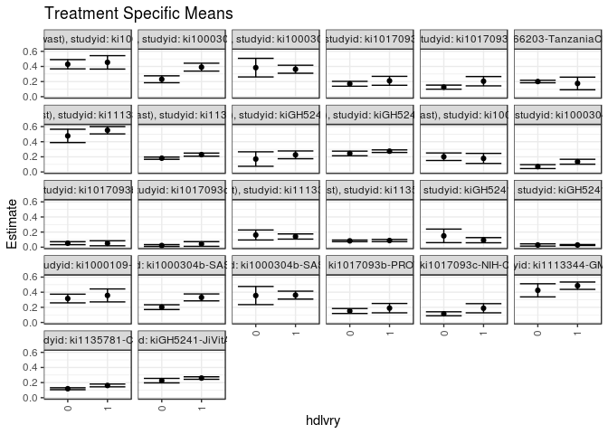

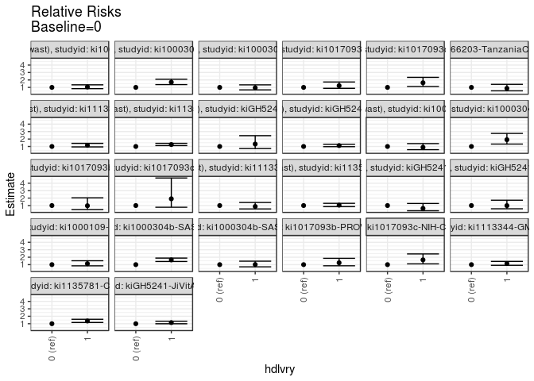

[figure not shown]

[figure not shown]

## Results Table

### Parameter: TSM

| agecat | studyid | country | intervention_level | baseline_level | estimate | ci_lower | ci_upper |
| --- | --- | --- | --- | --- | --- | --- | --- |
| 0-24 months (no birth wast) | ki1000109-EE | PAKISTAN | 0 | NA | 0.4291805 | 0.3679715 | 0.4903896 |
| 0-24 months (no birth wast) | ki1000109-EE | PAKISTAN | 1 | NA | 0.4540901 | 0.3653053 | 0.5428749 |
| 0-24 months (no birth wast) | ki1000304b-SAS-CompFeed | INDIA | 0 | NA | 0.2302158 | 0.1845479 | 0.2758837 |
| 0-24 months (no birth wast) | ki1000304b-SAS-CompFeed | INDIA | 1 | NA | 0.3906574 | 0.3384605 | 0.4428544 |
| 0-24 months (no birth wast) | ki1000304b-SAS-FoodSuppl | INDIA | 0 | NA | 0.3841367 | 0.2611754 | 0.5070980 |
| 0-24 months (no birth wast) | ki1000304b-SAS-FoodSuppl | INDIA | 1 | NA | 0.3629083 | 0.3101454 | 0.4156712 |
| 0-24 months (no birth wast) | ki1017093b-PROVIDE | BANGLADESH | 0 | NA | 0.1708424 | 0.1384870 | 0.2031978 |
| 0-24 months (no birth wast) | ki1017093b-PROVIDE | BANGLADESH | 1 | NA | 0.2098945 | 0.1508724 | 0.2689165 |
| 0-24 months (no birth wast) | ki1017093c-NIH-Crypto | BANGLADESH | 0 | NA | 0.1261985 | 0.0993125 | 0.1530846 |
| 0-24 months (no birth wast) | ki1017093c-NIH-Crypto | BANGLADESH | 1 | NA | 0.2046733 | 0.1429340 | 0.2664125 |
| 0-24 months (no birth wast) | ki1066203-TanzaniaChild2 | TANZANIA, UNITED REPUBLIC OF | 0 | NA | 0.2007201 | 0.1839373 | 0.2175028 |
| 0-24 months (no birth wast) | ki1066203-TanzaniaChild2 | TANZANIA, UNITED REPUBLIC OF | 1 | NA | 0.1750000 | 0.0916918 | 0.2583082 |
| 0-24 months (no birth wast) | ki1113344-GMS-Nepal | NEPAL | 0 | NA | 0.4768920 | 0.3887569 | 0.5650271 |
| 0-24 months (no birth wast) | ki1113344-GMS-Nepal | NEPAL | 1 | NA | 0.5516493 | 0.5032701 | 0.6000285 |
| 0-24 months (no birth wast) | ki1135781-COHORTS | INDIA | 0 | NA | 0.1817983 | 0.1670486 | 0.1965480 |
| 0-24 months (no birth wast) | ki1135781-COHORTS | INDIA | 1 | NA | 0.2291141 | 0.2084384 | 0.2497899 |
| 0-24 months (no birth wast) | kiGH5241-JiVitA-3 | BANGLADESH | 0 | NA | 0.1707317 | 0.0749030 | 0.2665604 |
| 0-24 months (no birth wast) | kiGH5241-JiVitA-3 | BANGLADESH | 1 | NA | 0.2262295 | 0.1750012 | 0.2774578 |
| 0-24 months (no birth wast) | kiGH5241-JiVitA-4 | BANGLADESH | 0 | NA | 0.2442041 | 0.2134115 | 0.2749966 |
| 0-24 months (no birth wast) | kiGH5241-JiVitA-4 | BANGLADESH | 1 | NA | 0.2746548 | 0.2576108 | 0.2916988 |
| 0-6 months (no birth wast) | ki1000109-EE | PAKISTAN | 0 | NA | 0.2013180 | 0.1513254 | 0.2513105 |
| 0-6 months (no birth wast) | ki1000109-EE | PAKISTAN | 1 | NA | 0.1790501 | 0.1124534 | 0.2456468 |
| 0-6 months (no birth wast) | ki1000304b-SAS-CompFeed | INDIA | 0 | NA | 0.0706315 | 0.0446041 | 0.0966589 |
| 0-6 months (no birth wast) | ki1000304b-SAS-CompFeed | INDIA | 1 | NA | 0.1348622 | 0.1024239 | 0.1673005 |
| 0-6 months (no birth wast) | ki1017093b-PROVIDE | BANGLADESH | 0 | NA | 0.0530452 | 0.0335604 | 0.0725299 |
| 0-6 months (no birth wast) | ki1017093b-PROVIDE | BANGLADESH | 1 | NA | 0.0517241 | 0.0187931 | 0.0846552 |
| 0-6 months (no birth wast) | ki1017093c-NIH-Crypto | BANGLADESH | 0 | NA | 0.0222603 | 0.0102871 | 0.0342334 |
| 0-6 months (no birth wast) | ki1017093c-NIH-Crypto | BANGLADESH | 1 | NA | 0.0424242 | 0.0116498 | 0.0731987 |
| 0-6 months (no birth wast) | ki1113344-GMS-Nepal | NEPAL | 0 | NA | 0.1613549 | 0.0952546 | 0.2274552 |
| 0-6 months (no birth wast) | ki1113344-GMS-Nepal | NEPAL | 1 | NA | 0.1412203 | 0.1069893 | 0.1754514 |
| 0-6 months (no birth wast) | ki1135781-COHORTS | INDIA | 0 | NA | 0.0836520 | 0.0727622 | 0.0945418 |
| 0-6 months (no birth wast) | ki1135781-COHORTS | INDIA | 1 | NA | 0.0880605 | 0.0735390 | 0.1025820 |
| 0-6 months (no birth wast) | kiGH5241-JiVitA-3 | BANGLADESH | 0 | NA | 0.1500000 | 0.0603230 | 0.2396770 |
| 0-6 months (no birth wast) | kiGH5241-JiVitA-3 | BANGLADESH | 1 | NA | 0.0927152 | 0.0586870 | 0.1267434 |
| 0-6 months (no birth wast) | kiGH5241-JiVitA-4 | BANGLADESH | 0 | NA | 0.0293905 | 0.0144802 | 0.0443008 |
| 0-6 months (no birth wast) | kiGH5241-JiVitA-4 | BANGLADESH | 1 | NA | 0.0290517 | 0.0231497 | 0.0349538 |
| 6-24 months | ki1000109-EE | PAKISTAN | 0 | NA | 0.3164738 | 0.2588822 | 0.3740653 |
| 6-24 months | ki1000109-EE | PAKISTAN | 1 | NA | 0.3574908 | 0.2718633 | 0.4431184 |
| 6-24 months | ki1000304b-SAS-CompFeed | INDIA | 0 | NA | 0.2023740 | 0.1708355 | 0.2339125 |
| 6-24 months | ki1000304b-SAS-CompFeed | INDIA | 1 | NA | 0.3312593 | 0.2856251 | 0.3768935 |
| 6-24 months | ki1000304b-SAS-FoodSuppl | INDIA | 0 | NA | 0.3559659 | 0.2360115 | 0.4759203 |
| 6-24 months | ki1000304b-SAS-FoodSuppl | INDIA | 1 | NA | 0.3614398 | 0.3089141 | 0.4139655 |
| 6-24 months | ki1017093b-PROVIDE | BANGLADESH | 0 | NA | 0.1515851 | 0.1188337 | 0.1843364 |
| 6-24 months | ki1017093b-PROVIDE | BANGLADESH | 1 | NA | 0.1894811 | 0.1277412 | 0.2512209 |
| 6-24 months | ki1017093c-NIH-Crypto | BANGLADESH | 0 | NA | 0.1147172 | 0.0884592 | 0.1409751 |
| 6-24 months | ki1017093c-NIH-Crypto | BANGLADESH | 1 | NA | 0.1881560 | 0.1274118 | 0.2489001 |
| 6-24 months | ki1113344-GMS-Nepal | NEPAL | 0 | NA | 0.4248939 | 0.3377885 | 0.5119993 |
| 6-24 months | ki1113344-GMS-Nepal | NEPAL | 1 | NA | 0.4860622 | 0.4375792 | 0.5345453 |
| 6-24 months | ki1135781-COHORTS | INDIA | 0 | NA | 0.1187588 | 0.1059602 | 0.1315575 |
| 6-24 months | ki1135781-COHORTS | INDIA | 1 | NA | 0.1619648 | 0.1436281 | 0.1803015 |
| 6-24 months | kiGH5241-JiVitA-4 | BANGLADESH | 0 | NA | 0.2257418 | 0.1960765 | 0.2554071 |
| 6-24 months | kiGH5241-JiVitA-4 | BANGLADESH | 1 | NA | 0.2599489 | 0.2432802 | 0.2766176 |

### Parameter: E(Y)

| agecat | studyid | country | intervention_level | baseline_level | estimate | ci_lower | ci_upper |
| --- | --- | --- | --- | --- | --- | --- | --- |
| 0-24 months (no birth wast) | ki1000109-EE | PAKISTAN | NA | NA | 0.4373333 | 0.3870592 | 0.4876074 |
| 0-24 months (no birth wast) | ki1000304b-SAS-CompFeed | INDIA | NA | NA | 0.3741830 | 0.3195305 | 0.4288355 |
| 0-24 months (no birth wast) | ki1000304b-SAS-FoodSuppl | INDIA | NA | NA | 0.3602015 | 0.3129196 | 0.4074834 |
| 0-24 months (no birth wast) | ki1017093b-PROVIDE | BANGLADESH | NA | NA | 0.1775837 | 0.1489858 | 0.2061816 |
| 0-24 months (no birth wast) | ki1017093c-NIH-Crypto | BANGLADESH | NA | NA | 0.1432361 | 0.1182149 | 0.1682572 |
| 0-24 months (no birth wast) | ki1066203-TanzaniaChild2 | TANZANIA, UNITED REPUBLIC OF | NA | NA | 0.2002653 | 0.1837694 | 0.2167611 |
| 0-24 months (no birth wast) | ki1113344-GMS-Nepal | NEPAL | NA | NA | 0.5290909 | 0.4873371 | 0.5708447 |
| 0-24 months (no birth wast) | ki1135781-COHORTS | INDIA | NA | NA | 0.1973899 | 0.1862487 | 0.2085311 |
| 0-24 months (no birth wast) | kiGH5241-JiVitA-3 | BANGLADESH | NA | NA | 0.2196532 | 0.1732957 | 0.2660107 |
| 0-24 months (no birth wast) | kiGH5241-JiVitA-4 | BANGLADESH | NA | NA | 0.2665179 | 0.2514258 | 0.2816100 |
| 0-6 months (no birth wast) | ki1000109-EE | PAKISTAN | NA | NA | 0.1913747 | 0.1512914 | 0.2314579 |
| 0-6 months (no birth wast) | ki1000304b-SAS-CompFeed | INDIA | NA | NA | 0.1289517 | 0.0982960 | 0.1596075 |
| 0-6 months (no birth wast) | ki1017093b-PROVIDE | BANGLADESH | NA | NA | 0.0527086 | 0.0359384 | 0.0694789 |
| 0-6 months (no birth wast) | ki1017093c-NIH-Crypto | BANGLADESH | NA | NA | 0.0267023 | 0.0151493 | 0.0382553 |
| 0-6 months (no birth wast) | ki1113344-GMS-Nepal | NEPAL | NA | NA | 0.1417769 | 0.1120237 | 0.1715302 |
| 0-6 months (no birth wast) | ki1135781-COHORTS | INDIA | NA | NA | 0.0846222 | 0.0765129 | 0.0927314 |
| 0-6 months (no birth wast) | kiGH5241-JiVitA-3 | BANGLADESH | NA | NA | 0.0994152 | 0.0685873 | 0.1302431 |
| 0-6 months (no birth wast) | kiGH5241-JiVitA-4 | BANGLADESH | NA | NA | 0.0286500 | 0.0232922 | 0.0340079 |
| 6-24 months | ki1000109-EE | PAKISTAN | NA | NA | 0.3297587 | 0.2819849 | 0.3775326 |
| 6-24 months | ki1000304b-SAS-CompFeed | INDIA | NA | NA | 0.3164894 | 0.2686679 | 0.3643108 |
| 6-24 months | ki1000304b-SAS-FoodSuppl | INDIA | NA | NA | 0.3557214 | 0.3088651 | 0.4025777 |
| 6-24 months | ki1017093b-PROVIDE | BANGLADESH | NA | NA | 0.1609756 | 0.1319065 | 0.1900447 |
| 6-24 months | ki1017093c-NIH-Crypto | BANGLADESH | NA | NA | 0.1315068 | 0.1069744 | 0.1560393 |
| 6-24 months | ki1113344-GMS-Nepal | NEPAL | NA | NA | 0.4717668 | 0.4299709 | 0.5135628 |
| 6-24 months | ki1135781-COHORTS | INDIA | NA | NA | 0.1326445 | 0.1229894 | 0.1422995 |
| 6-24 months | kiGH5241-JiVitA-4 | BANGLADESH | NA | NA | 0.2511131 | 0.2362659 | 0.2659603 |

### Parameter: RR

| agecat | studyid | country | intervention_level | baseline_level | estimate | ci_lower | ci_upper |
| --- | --- | --- | --- | --- | --- | --- | --- |
| 0-24 months (no birth wast) | ki1000109-EE | PAKISTAN | 0 | 0 | 1.0000000 | 1.0000000 | 1.000000 |
| 0-24 months (no birth wast) | ki1000109-EE | PAKISTAN | 1 | 0 | 1.0580399 | 0.8318432 | 1.345744 |
| 0-24 months (no birth wast) | ki1000304b-SAS-CompFeed | INDIA | 0 | 0 | 1.0000000 | 1.0000000 | 1.000000 |
| 0-24 months (no birth wast) | ki1000304b-SAS-CompFeed | INDIA | 1 | 0 | 1.6969182 | 1.3746670 | 2.094712 |
| 0-24 months (no birth wast) | ki1000304b-SAS-FoodSuppl | INDIA | 0 | 0 | 1.0000000 | 1.0000000 | 1.000000 |
| 0-24 months (no birth wast) | ki1000304b-SAS-FoodSuppl | INDIA | 1 | 0 | 0.9447374 | 0.6647292 | 1.342695 |
| 0-24 months (no birth wast) | ki1017093b-PROVIDE | BANGLADESH | 0 | 0 | 1.0000000 | 1.0000000 | 1.000000 |
| 0-24 months (no birth wast) | ki1017093b-PROVIDE | BANGLADESH | 1 | 0 | 1.2285853 | 0.8761620 | 1.722766 |
| 0-24 months (no birth wast) | ki1017093c-NIH-Crypto | BANGLADESH | 0 | 0 | 1.0000000 | 1.0000000 | 1.000000 |
| 0-24 months (no birth wast) | ki1017093c-NIH-Crypto | BANGLADESH | 1 | 0 | 1.6218357 | 1.1210526 | 2.346323 |
| 0-24 months (no birth wast) | ki1066203-TanzaniaChild2 | TANZANIA, UNITED REPUBLIC OF | 0 | 0 | 1.0000000 | 1.0000000 | 1.000000 |
| 0-24 months (no birth wast) | ki1066203-TanzaniaChild2 | TANZANIA, UNITED REPUBLIC OF | 1 | 0 | 0.8718610 | 0.5376976 | 1.413697 |
| 0-24 months (no birth wast) | ki1113344-GMS-Nepal | NEPAL | 0 | 0 | 1.0000000 | 1.0000000 | 1.000000 |
| 0-24 months (no birth wast) | ki1113344-GMS-Nepal | NEPAL | 1 | 0 | 1.1567593 | 0.9426364 | 1.419521 |
| 0-24 months (no birth wast) | ki1135781-COHORTS | INDIA | 0 | 0 | 1.0000000 | 1.0000000 | 1.000000 |
| 0-24 months (no birth wast) | ki1135781-COHORTS | INDIA | 1 | 0 | 1.2602654 | 1.1165276 | 1.422508 |
| 0-24 months (no birth wast) | kiGH5241-JiVitA-3 | BANGLADESH | 0 | 0 | 1.0000000 | 1.0000000 | 1.000000 |
| 0-24 months (no birth wast) | kiGH5241-JiVitA-3 | BANGLADESH | 1 | 0 | 1.3250585 | 0.7169637 | 2.448911 |
| 0-24 months (no birth wast) | kiGH5241-JiVitA-4 | BANGLADESH | 0 | 0 | 1.0000000 | 1.0000000 | 1.000000 |
| 0-24 months (no birth wast) | kiGH5241-JiVitA-4 | BANGLADESH | 1 | 0 | 1.1246937 | 0.9769165 | 1.294825 |
| 0-6 months (no birth wast) | ki1000109-EE | PAKISTAN | 0 | 0 | 1.0000000 | 1.0000000 | 1.000000 |
| 0-6 months (no birth wast) | ki1000109-EE | PAKISTAN | 1 | 0 | 0.8893896 | 0.5692173 | 1.389652 |
| 0-6 months (no birth wast) | ki1000304b-SAS-CompFeed | INDIA | 0 | 0 | 1.0000000 | 1.0000000 | 1.000000 |
| 0-6 months (no birth wast) | ki1000304b-SAS-CompFeed | INDIA | 1 | 0 | 1.9093779 | 1.3249110 | 2.751675 |
| 0-6 months (no birth wast) | ki1017093b-PROVIDE | BANGLADESH | 0 | 0 | 1.0000000 | 1.0000000 | 1.000000 |
| 0-6 months (no birth wast) | ki1017093b-PROVIDE | BANGLADESH | 1 | 0 | 0.9750958 | 0.4675489 | 2.033609 |
| 0-6 months (no birth wast) | ki1017093c-NIH-Crypto | BANGLADESH | 0 | 0 | 1.0000000 | 1.0000000 | 1.000000 |
| 0-6 months (no birth wast) | ki1017093c-NIH-Crypto | BANGLADESH | 1 | 0 | 1.9058275 | 0.7724891 | 4.701916 |
| 0-6 months (no birth wast) | ki1113344-GMS-Nepal | NEPAL | 0 | 0 | 1.0000000 | 1.0000000 | 1.000000 |
| 0-6 months (no birth wast) | ki1113344-GMS-Nepal | NEPAL | 1 | 0 | 0.8752157 | 0.5430314 | 1.410605 |
| 0-6 months (no birth wast) | ki1135781-COHORTS | INDIA | 0 | 0 | 1.0000000 | 1.0000000 | 1.000000 |
| 0-6 months (no birth wast) | ki1135781-COHORTS | INDIA | 1 | 0 | 1.0527010 | 0.8532205 | 1.298819 |
| 0-6 months (no birth wast) | kiGH5241-JiVitA-3 | BANGLADESH | 0 | 0 | 1.0000000 | 1.0000000 | 1.000000 |
| 0-6 months (no birth wast) | kiGH5241-JiVitA-3 | BANGLADESH | 1 | 0 | 0.6181015 | 0.2989442 | 1.277996 |
| 0-6 months (no birth wast) | kiGH5241-JiVitA-4 | BANGLADESH | 0 | 0 | 1.0000000 | 1.0000000 | 1.000000 |
| 0-6 months (no birth wast) | kiGH5241-JiVitA-4 | BANGLADESH | 1 | 0 | 0.9884736 | 0.5683075 | 1.719280 |
| 6-24 months | ki1000109-EE | PAKISTAN | 0 | 0 | 1.0000000 | 1.0000000 | 1.000000 |
| 6-24 months | ki1000109-EE | PAKISTAN | 1 | 0 | 1.1296064 | 0.8374351 | 1.523713 |
| 6-24 months | ki1000304b-SAS-CompFeed | INDIA | 0 | 0 | 1.0000000 | 1.0000000 | 1.000000 |
| 6-24 months | ki1000304b-SAS-CompFeed | INDIA | 1 | 0 | 1.6368669 | 1.4243516 | 1.881090 |
| 6-24 months | ki1000304b-SAS-FoodSuppl | INDIA | 0 | 0 | 1.0000000 | 1.0000000 | 1.000000 |
| 6-24 months | ki1000304b-SAS-FoodSuppl | INDIA | 1 | 0 | 1.0153776 | 0.7033448 | 1.465841 |
| 6-24 months | ki1017093b-PROVIDE | BANGLADESH | 0 | 0 | 1.0000000 | 1.0000000 | 1.000000 |
| 6-24 months | ki1017093b-PROVIDE | BANGLADESH | 1 | 0 | 1.2499981 | 0.8458529 | 1.847242 |
| 6-24 months | ki1017093c-NIH-Crypto | BANGLADESH | 0 | 0 | 1.0000000 | 1.0000000 | 1.000000 |
| 6-24 months | ki1017093c-NIH-Crypto | BANGLADESH | 1 | 0 | 1.6401728 | 1.1042893 | 2.436107 |
| 6-24 months | ki1113344-GMS-Nepal | NEPAL | 0 | 0 | 1.0000000 | 1.0000000 | 1.000000 |
| 6-24 months | ki1113344-GMS-Nepal | NEPAL | 1 | 0 | 1.1439615 | 0.9105877 | 1.437147 |
| 6-24 months | ki1135781-COHORTS | INDIA | 0 | 0 | 1.0000000 | 1.0000000 | 1.000000 |
| 6-24 months | ki1135781-COHORTS | INDIA | 1 | 0 | 1.3638130 | 1.1670161 | 1.593796 |
| 6-24 months | kiGH5241-JiVitA-4 | BANGLADESH | 0 | 0 | 1.0000000 | 1.0000000 | 1.000000 |
| 6-24 months | kiGH5241-JiVitA-4 | BANGLADESH | 1 | 0 | 1.1515322 | 0.9957150 | 1.331733 |

### Parameter: PAR

| agecat | studyid | country | intervention_level | baseline_level | estimate | ci_lower | ci_upper |
| --- | --- | --- | --- | --- | --- | --- | --- |
| 0-24 months (no birth wast) | ki1000109-EE | PAKISTAN | 0 | NA | 0.0081528 | -0.0265352 | 0.0428408 |
| 0-24 months (no birth wast) | ki1000304b-SAS-CompFeed | INDIA | 0 | NA | 0.1439672 | 0.0897950 | 0.1981394 |
| 0-24 months (no birth wast) | ki1000304b-SAS-FoodSuppl | INDIA | 0 | NA | -0.0239352 | -0.1366112 | 0.0887409 |
| 0-24 months (no birth wast) | ki1017093b-PROVIDE | BANGLADESH | 0 | NA | 0.0067413 | -0.0106494 | 0.0241320 |
| 0-24 months (no birth wast) | ki1017093c-NIH-Crypto | BANGLADESH | 0 | NA | 0.0170376 | 0.0020465 | 0.0320286 |
| 0-24 months (no birth wast) | ki1066203-TanzaniaChild2 | TANZANIA, UNITED REPUBLIC OF | 0 | NA | -0.0004548 | -0.0025840 | 0.0016743 |
| 0-24 months (no birth wast) | ki1113344-GMS-Nepal | NEPAL | 0 | NA | 0.0521989 | -0.0253358 | 0.1297336 |
| 0-24 months (no birth wast) | ki1135781-COHORTS | INDIA | 0 | NA | 0.0155916 | 0.0052440 | 0.0259391 |
| 0-24 months (no birth wast) | kiGH5241-JiVitA-3 | BANGLADESH | 0 | NA | 0.0489215 | -0.0484409 | 0.1462839 |
| 0-24 months (no birth wast) | kiGH5241-JiVitA-4 | BANGLADESH | 0 | NA | 0.0223138 | -0.0038900 | 0.0485175 |
| 0-6 months (no birth wast) | ki1000109-EE | PAKISTAN | 0 | NA | -0.0099433 | -0.0375045 | 0.0176180 |
| 0-6 months (no birth wast) | ki1000304b-SAS-CompFeed | INDIA | 0 | NA | 0.0583203 | 0.0263022 | 0.0903383 |
| 0-6 months (no birth wast) | ki1017093b-PROVIDE | BANGLADESH | 0 | NA | -0.0003365 | -0.0100846 | 0.0094115 |
| 0-6 months (no birth wast) | ki1017093c-NIH-Crypto | BANGLADESH | 0 | NA | 0.0044420 | -0.0028570 | 0.0117410 |
| 0-6 months (no birth wast) | ki1113344-GMS-Nepal | NEPAL | 0 | NA | -0.0195780 | -0.0784069 | 0.0392509 |
| 0-6 months (no birth wast) | ki1135781-COHORTS | INDIA | 0 | NA | 0.0009702 | -0.0063339 | 0.0082743 |
| 0-6 months (no birth wast) | kiGH5241-JiVitA-3 | BANGLADESH | 0 | NA | -0.0505848 | -0.1374669 | 0.0362973 |
| 0-6 months (no birth wast) | kiGH5241-JiVitA-4 | BANGLADESH | 0 | NA | -0.0007405 | -0.0133443 | 0.0118633 |
| 6-24 months | ki1000109-EE | PAKISTAN | 0 | NA | 0.0132849 | -0.0200352 | 0.0466051 |
| 6-24 months | ki1000304b-SAS-CompFeed | INDIA | 0 | NA | 0.1141154 | 0.0795912 | 0.1486395 |
| 6-24 months | ki1000304b-SAS-FoodSuppl | INDIA | 0 | NA | -0.0002445 | -0.1099869 | 0.1094979 |
| 6-24 months | ki1017093b-PROVIDE | BANGLADESH | 0 | NA | 0.0093905 | -0.0084157 | 0.0271967 |
| 6-24 months | ki1017093c-NIH-Crypto | BANGLADESH | 0 | NA | 0.0167897 | 0.0019122 | 0.0316672 |
| 6-24 months | ki1113344-GMS-Nepal | NEPAL | 0 | NA | 0.0468730 | -0.0296432 | 0.1233891 |
| 6-24 months | ki1135781-COHORTS | INDIA | 0 | NA | 0.0138856 | 0.0045994 | 0.0231719 |
| 6-24 months | kiGH5241-JiVitA-4 | BANGLADESH | 0 | NA | 0.0253713 | 0.0002848 | 0.0504578 |

### Parameter: PAF

| agecat | studyid | country | intervention_level | baseline_level | estimate | ci_lower | ci_upper |
| --- | --- | --- | --- | --- | --- | --- | --- |
| 0-24 months (no birth wast) | ki1000109-EE | PAKISTAN | 0 | NA | 0.0186420 | -0.0640104 | 0.0948741 |
| 0-24 months (no birth wast) | ki1000304b-SAS-CompFeed | INDIA | 0 | NA | 0.3847507 | 0.2564679 | 0.4909007 |
| 0-24 months (no birth wast) | ki1000304b-SAS-FoodSuppl | INDIA | 0 | NA | -0.0664494 | -0.4299327 | 0.2046379 |
| 0-24 months (no birth wast) | ki1017093b-PROVIDE | BANGLADESH | 0 | NA | 0.0379613 | -0.0648374 | 0.1308358 |
| 0-24 months (no birth wast) | ki1017093c-NIH-Crypto | BANGLADESH | 0 | NA | 0.1189474 | 0.0094960 | 0.2163043 |
| 0-24 months (no birth wast) | ki1066203-TanzaniaChild2 | TANZANIA, UNITED REPUBLIC OF | 0 | NA | -0.0022711 | -0.0129474 | 0.0082927 |
| 0-24 months (no birth wast) | ki1113344-GMS-Nepal | NEPAL | 0 | NA | 0.0986577 | -0.0607324 | 0.2340971 |
| 0-24 months (no birth wast) | ki1135781-COHORTS | INDIA | 0 | NA | 0.0789886 | 0.0251248 | 0.1298763 |
| 0-24 months (no birth wast) | kiGH5241-JiVitA-3 | BANGLADESH | 0 | NA | 0.2227214 | -0.3565950 | 0.5546483 |
| 0-24 months (no birth wast) | kiGH5241-JiVitA-4 | BANGLADESH | 0 | NA | 0.0837234 | -0.0204165 | 0.1772351 |
| 0-6 months (no birth wast) | ki1000109-EE | PAKISTAN | 0 | NA | -0.0519572 | -0.2060187 | 0.0824240 |
| 0-6 months (no birth wast) | ki1000304b-SAS-CompFeed | INDIA | 0 | NA | 0.4522642 | 0.2174265 | 0.6166309 |
| 0-6 months (no birth wast) | ki1017093b-PROVIDE | BANGLADESH | 0 | NA | -0.0063851 | -0.2094002 | 0.1625511 |
| 0-6 months (no birth wast) | ki1017093c-NIH-Crypto | BANGLADESH | 0 | NA | 0.1663527 | -0.1444437 | 0.3927462 |
| 0-6 months (no birth wast) | ki1113344-GMS-Nepal | NEPAL | 0 | NA | -0.1380899 | -0.6399481 | 0.2101892 |
| 0-6 months (no birth wast) | ki1135781-COHORTS | INDIA | 0 | NA | 0.0114649 | -0.0787316 | 0.0941198 |
| 0-6 months (no birth wast) | kiGH5241-JiVitA-3 | BANGLADESH | 0 | NA | -0.5088235 | -1.7418198 | 0.1696944 |
| 0-6 months (no birth wast) | kiGH5241-JiVitA-4 | BANGLADESH | 0 | NA | -0.0258458 | -0.5732888 | 0.3311084 |
| 6-24 months | ki1000109-EE | PAKISTAN | 0 | NA | 0.0402868 | -0.0663011 | 0.1362201 |
| 6-24 months | ki1000304b-SAS-CompFeed | INDIA | 0 | NA | 0.3605662 | 0.2787635 | 0.4330909 |
| 6-24 months | ki1000304b-SAS-FoodSuppl | INDIA | 0 | NA | -0.0006873 | -0.3620357 | 0.2647952 |
| 6-24 months | ki1017093b-PROVIDE | BANGLADESH | 0 | NA | 0.0583351 | -0.0585779 | 0.1623359 |
| 6-24 months | ki1017093c-NIH-Crypto | BANGLADESH | 0 | NA | 0.1276716 | 0.0090047 | 0.2321287 |
| 6-24 months | ki1113344-GMS-Nepal | NEPAL | 0 | NA | 0.0993562 | -0.0786181 | 0.2479645 |
| 6-24 months | ki1135781-COHORTS | INDIA | 0 | NA | 0.1046831 | 0.0321356 | 0.1717928 |
| 6-24 months | kiGH5241-JiVitA-4 | BANGLADESH | 0 | NA | 0.1010355 | -0.0050981 | 0.1959618 |